# NFL Play By Play Data: Part I

Vishal Bakshi  
September 26, 2017  
vbakshi@ccsf.edu

Source: [Kaggle](https://www.kaggle.com/maxhorowitz/nflplaybyplay2015)

## Objective

Carnegie Mellon University's Statistics department, led by Maksim Horowitz, released the <a href = "[https://github.com/maksimhorowitz/nflscrapR">nflscrapR](https://github.com/maksimhorowitz/nflscrapR)</a> R package with which this data was obtained and posted on Kaggle as a CSV file. I explore this data in this post and my focus is to gain some more fluency with SQL queries.

### Creating the Table Schema

I started by importing the CSV into a pandas DataFrame using `pd.read_csv()` and specified the dtype as either `numpy.int` (`8` or `32`), `numpy.float16`, or `str` for each column. The original CSV contained `NA` and empty string values which I replaced with '\N', the NULL value equivalent for SQL, using `df.fillna('NA', '\N')` and `df.replace('','\N')`. I created a `nfl_table.sql` batch file to create the table in MySQL, which can be viewed here. Additionally, I modified the header in the CSV to remove the periods (`.`) from column names (such as `Yards.Gained`) since this may conflict with SQL's database.table or table.column queries. I also added an `Idx` header for the first column, which was originally blank, so that I could use it as the table's primary key.

Once created, I validated the MySQL table `plays` with the pandas Dataframe using `Dataframe.column.value_counts`.

### Initial Data Summaries

I start out by asking some summarizing questions:

- In the 2015 Season, what was the average:
  - `YardsGained` for `Complete` passes versus rush attempts?
  - `FieldGoalDistance` for `Good`, `No Good` and `Blocked` field goals?
  - `YardsGained` for `Short` versus `Deep` passes?
- In the 2015 Season, what were the percentages of different:
  - `RunLocation` values: `left`, `middle` and `right`?
  - `PassOutcome` values: `Complete` versus `Incomplete Pass`?
  - `PassLength` values: `Short` versus `Deep`?

The corresponding queries and result are shown below:

```
-- Query 1: YardsGained for Complete passes versus rush attempts
SELECT  p.PlayType,
        AVG(p.YardsGained) AS AvgYdsGained
FROM plays p
JOIN plays p1
 ON p1.Idx = p.Idx
JOIN plays p2
 ON p2.Idx = p.Idx
WHERE (p1.PlayType = 'Pass' AND p1.PassOutcome = 'Complete') OR (p2.PlayType = 'Run')
GROUP BY p.PlayType;
```

[figure not shown]

**Figure 1:** Query 1 Results

```
-- Query 2: FieldGoalDistance for Good field goals versus No Good field goals
SELECT  p.FieldGoalResult AS FG_Result,
        AVG(p.FieldGoalDistance) AS AverageFieldGoalDistance
FROM plays p
WHERE p.FieldGoalResult IS NOT NULL
GROUP BY FG_Result;
```

[figure not shown]

**Figure 2:** Query 2 Results

```
-- Query 3: YardsGained for Short versus Deep passes
SELECT  p.PassOutcome,
        p.PassLength,
        AVG(YardsGained) AS AvgPassYds
FROM plays p
WHERE p.PassOutcome = 'Complete' AND p.PassLength IS NOT NULL
GROUP BY p.PassLength;
```

[figure not shown]

**Figure 3:** Query 3 Results

```
-- Query 4: Percentage of different RunLocation values: left, middle and right
SELECT COUNT(*)
FROM plays
WHERE plays.PlayType = 'Run'
INTO @totalrunplays;

SELECT  p.RunLocation,
        COUNT(1) / @totalrunplays * 100 AS Percentage
FROM plays p
WHERE p.RunLocation IS NOT NULL
GROUP BY p.RunLocation;
```

[figure not shown]

**Figure 4:** Query 4 Results

```
-- Query 5: Percentage of different PassOutcome values: Complete versus Incomplete Pass
SELECT COUNT(*)
FROM plays
WHERE plays.PlayType = 'Pass'
INTO @totalpassplays;

SELECT  p.PassOutcome,
        COUNT(*) / @totalpassplays * 100 AS Percentage
FROM plays p
WHERE p.PassOutcome IS NOT NULL
GROUP BY p.PassOutcome;
```

[figure not shown]

**Figure 5:** Query 5 Results

```
-- Query 6: Percentage of different PassLength values: Short versus Deep
SELECT COUNT(*)
FROM plays
WHERE plays.PassOutcome = 'Complete'
INTO @totalcompletepasses;

SELECT  p.PassOutcome,
        p.PassLength,
        COUNT(*) / @totalcompletepasses * 100 AS Percentage
FROM plays p
WHERE p.PassOutcome = 'Complete' AND p.PassLength IS NOT NULL
GROUP BY p.PassLength;
```

[figure not shown]

**Figure 6:** Query 6 Results

### Philadelphia Eagles Play-By-Play Analysis

I want to explore the trends present in my beloved Eagles' plays during the 2015 season. The roster was significantly different than the current season, with different starters at critical offensive and defensive positions as well a different head coach so the results will not translate to any insights for the 2017 season. Initially, I view the summary of play counts by `PlayType` for all recorded Eagles' possessions:

```
-- Query 7: Summary of PlayType for Philadelphia Eagles' possessions
SELECT  p.PlayType,
        COUNT(p.PlayType),
        p.posteam
FROM plays p
WHERE p.posteam = 'PHI'
GROUP BY p.PlayType
ORDER BY COUNT(p.PlayType) DESC;
```

[figure not shown]

**Figure 7:** Query 7 Results

Next, I extract the top 10 receivers (based on # of passes caught) and their average `YardsGained` per complete reception, and total `YardsGained` across all recorded receptions:

```
-- Query 8: Total YardsGained, Average YardsGained for top 10 receivers (based on Number of Passes caught)
SELECT  p.PlayType,
        p.PassOutcome,
        p.Receiver,
        AVG(p.YardsGained),
        SUM(p.YardsGained), COUNT(*) AS PassesCaught
FROM plays p
WHERE p.PassOutcome = 'Complete' AND p.PlayType = 'Pass' AND p.posteam ='PHI'
GROUP BY p.Receiver
ORDER BY COUNT(*) DESC, SUM(p.YardsGained) DESC, AVG(p.YardsGained) DESC
LIMIT 10;
```

[figure not shown]

**Figure 8:** Query 8 Results

I then extract the top rushers (based on number of rushing attempts) and average `YardsGained` for each `RunLocation` of `left`, `middle` and `right`.

```
-- Query 9: Top rushers (based on number of rushing attempts) and their average YardsGained for each RunLocation
SELECT  p.posteam,
        p.PlayType,
        p.Rusher,
        COUNT(*) AS RushAttempts,
        p.RunLocation,
        AVG(p.YardsGained)
FROM plays p
WHERE p.PlayType = 'Run' AND p.posteam = 'PHI' AND p.Rusher IS NOT NULL AND p.RunLocation IS NOT NULL
GROUP BY p.Rusher, p.RunLocation
ORDER BY p.Rusher, COUNT(*) DESC, AVG(p.YardsGained) DESC
LIMIT 10;
```

[figure not shown]

**Figure 9:** Query 9 Results

The starting running back (Demarco Murray) had the highest number of RushAttempts overall, with the highest average `YardsGained` when he rushed to the `middle`. Interestingly enough, he had the fewest attempts in that direction. The second most used running back (Darren Sproles) was more successful when he rushed `right`, which was also the direction in which he ran the most.

A more interesting analysis is to identify the most successful rushing attempts based on how well the opposing team defended the run. I'll measure a team's effectiveness at defending the run based on the average `YardsGained` per rush attempt against their defense. First I extract the top 10 teams with the lowest average rushing `YardsGained` allowed all season:

```
-- Query 10: Top 10 teams with the lowest average rushing YardsGained allowed all season
SELECT  p.DefensiveTeam,
        p.PlayType,
        AVG(p.YardsGained) AS Yards_Per_Rush_Attempt
FROM plays p
WHERE p.PlayType = 'Run' AND p.DefensiveTeam IS NOT NULL
GROUP BY p.DefensiveTeam
ORDER BY AVG(p.YardsGained)
LIMIT 10;
```

[figure not shown]

**Figure 10:** Query 10 Results

Next I'll compare Philadelphia's success on rush attempts versus those top 10 teams:

```
-- Query 11: Eagles' average YardsGained per rush attempt against top 10 defenses (based on average rushing YardsGained allowed per game over season)
SELECT  p2.posteam AS Offense,
        TopDefRush.DefensiveTeam AS Defense,
        p2.PlayType,
        AVG(p2.YardsGained) AS Philly_AvgRushYds,
        TopDefRush.Yards_Per_Rush_Attempt AS AllTeams_AvgRushYds,
        AVG(p2.YardsGained) - TopDefRush.Yards_Per_Rush_Attempt AS AvgRushYds_Diff
FROM (
    SELECT  p1.DefensiveTeam,
            p1.PlayType,
            AVG(p1.YardsGained) AS Yards_Per_Rush_Attempt
    FROM plays p1
    WHERE p1.PlayType = 'Run' AND p1.DefensiveTeam IS NOT NULL
    GROUP BY p1.DefensiveTeam
    ORDER BY AVG(p1.YardsGained) LIMIT 0,10) AS TopDefRush
INNER JOIN plays p2
 ON p2.DefensiveTeam = TopDefRush.DefensiveTeam
WHERE p2.posteam = 'PHI' AND p2.PlayType = 'Run'
GROUP BY TopDefRush.DefensiveTeam
ORDER BY AVG(p2.YardsGained) DESC;
```

[figure not shown]

**Figure 11:** Query 11 Results

The Eagles faced 5 of the top 10 defenses (based on average rushing yards allowed per rush attempt), rushed more yards than average against the Carolina Panthers and the Tampa Bay Buccaneers and rushed fewer yards than average against the New England Patriots, Arizona Cardinals and New York Jets.

Based on this, it seems that the opposing defense's effectiveness against the run does not seem to dictate how well the Eagles run the ball. To further explore this point, I'll compare Philadelphia's success on rush attempts versus the bottom 10 defenses--the 10 defensive units which allowed the most average rushing yards per attempt over the season.

```
-- Query 12: Eagles' average YardsGained per rush attempt against bottom 10 defenses (based on average rushing YardsGained allowed per game over season)
SELECT p2.posteam AS Offense,
        BottomDefRush.DefensiveTeam AS Defense,
        p2.PlayType,
        AVG(p2.YardsGained) AS Philly_AvgRushYds,
        BottomDefRush.Yards_Per_Rush_Attempt AS AllTeams_AvgRushYds,
        AVG(p2.YardsGained) - BottomDefRush.Yards_Per_Rush_Attempt AS AvgRushYds_Diff
FROM (
    SELECT  p1.DefensiveTeam,
            p1.PlayType,
            AVG(p1.YardsGained) AS Yards_Per_Rush_Attempt
    FROM plays p1
    WHERE p1.PlayType = 'Run' AND p1.DefensiveTeam IS NOT NULL
    GROUP BY p1.DefensiveTeam
    ORDER BY AVG(p1.YardsGained) DESC LIMIT 0, 10) AS BottomDefRush
 INNER JOIN plays p2
  ON p2.DefensiveTeam = BottomDefRush.DefensiveTeam
WHERE p2.posteam = 'PHI' AND p2.PlayType = 'Run'
GROUP BY BottomDefRush.DefensiveTeam
ORDER BY AVG(p2.YardsGained) DESC;
```

[figure not shown]

**Figure 12:** Query 12 Results

Again, the results are unclear. Against the four worst run defenses (based on average `YardsGained` per rush attempt) the Eagles gain more yards than average against two (New Orleans Saints and New York Giants) and fewer yards than average against the other two (Washington Redskins and Buffalo Bills).

Next I extract the difference in average `YardsGained` by the Eagles against a particular team, based on `RunLocation`, versus the average `YardsGained` against those same defenses by all other teams.

```
-- Query 13: Opposing defense effectiveness based on RunLocation versus the Eagles' average YardsGained in that direction
SELECT  p2.PlayType,
        p2.RunLocation,
        AVG(p2.YardsGained) AS AllTeams_RushAvg,
        p3.PHI_RushAvg AS PHI_RushAvg, p3.PHI_RushAttempts
FROM (
    SELECT  DISTINCT DefensiveTeam AS DefTeam,
            posteam
    FROM plays
    WHERE posteam = 'PHI') AS p1
JOIN plays p2
ON p2.DefensiveTeam = p1.DefTeam
JOIN (
    SELECT  posteam,
            PlayType,
            RunLocation AS PhiRunLocation,
            AVG(YardsGained) AS PHI_RushAvg,
            COUNT(*) AS PHI_RushAttempts
    FROM plays
    WHERE posteam = 'PHI' AND PlayType = 'Run' AND RunLocation IS NOT NULL
    GROUP BY RunLocation) AS p3
 ON p2.RunLocation = p3.PhiRunLocation
WHERE p2.PlayType = 'Run' AND p2.RunLocation IS NOT NULL
GROUP BY p2.RunLocation
ORDER BY AVG(p2.YardsGained) DESC;
```

[figure not shown]

**Figure 13:** Query 13 Results

The Eagles performed above average when rushing toward the `middle` against teams who were strong against `middle` runs. They were below average when rushing toward the `left` and `right` against teams who were strong against runs in those directions. Interestingly enough, the Eagles had the fewest number of rush attempts toward the `middle` (121 attempts) even though they beat the average in that direction.

I run a similar query for completed passes, comparing the Eagles' average `YardsGained` on `Short` and `Deep` passes to the average for all teams.

```
-- Query 14: Opposing defense effectiveness based on PassLength versus the Eagles' average YardsGained in that direction
SELECT  p2.PassOutcome,
        p2.PassLength,
        AVG(p2.YardsGained) AS AllTeams_PassAvg,
        p3.PHI_PassAvg AS PHI_PassAvg
FROM (
    SELECT  DISTINCT DefensiveTeam AS DefTeam,
            posteam
    FROM plays
    WHERE posteam = 'PHI') AS p1
JOIN plays p2
ON p2.DefensiveTeam = p1.DefTeam
JOIN (
    SELECT  posteam,
            PassOutcome,
            PassLength AS PhiPassLength,
            AVG(YardsGained) AS PHI_PassAvg,
            COUNT(*) AS PHI_CompletePasses
    FROM plays
    WHERE posteam = 'PHI' AND PassOutcome = 'Complete' AND PassLength IS NOT NULL
    GROUP BY PassLength) AS p3
 ON p2.PassLength = p3.PhiPassLength
WHERE p2.PassOutcome = 'Complete' AND p2.PassLength IS NOT NULL
GROUP BY p2.PassLength
ORDER BY AVG(p2.YardsGained) DESC;
```

[figure not shown]

**Figure 14:** Query 14 Results

The Eagles completed more `Short` than `Deep` passes, beat the average on `Deep` passes and performed below average for `Short` passes. A more insightful query would show compare their completion percentage for `Short` versus `Deep` passes versus all teams' against common defensive units.

```
-- Query 15: Eagles pass completion percentage versus all teams' against common defensive units for Short and Deep passes
SELECT COUNT(*)
FROM plays
WHERE plays.posteam = 'PHI' AND plays.PlayType = 'Pass'
INTO @eaglespassplays;


SELECT  COUNT(*)
FROM (
    SELECT DISTINCT DefensiveTeam AS DefTeam, posteam FROM plays WHERE posteam = 'PHI') AS p1
JOIN plays p2
 ON p2.DefensiveTeam = p1.DefTeam
WHERE p2.PlayType = 'Pass'
INTO @totalpassplays;

SELECT  p2.PassOutcome,
        p2.PassLength,
        AVG(p2.YardsGained) AS AllTeams_PassAvg,
        p3.PHI_PassAvg AS PHI_PassAvg,
        COUNT(*) / @totalpassplays * 100 AS AllTeams_CompletionPercentage,
        p3.PHI_CompletePasses / @eaglespassplays * 100 AS PHI_CompletionPercentage
FROM (
    SELECT DISTINCT DefensiveTeam AS DefTeam, posteam FROM plays WHERE posteam = 'PHI') AS p1
JOIN plays p2
 ON p2.DefensiveTeam = p1.DefTeam
JOIN (
    SELECT  posteam,
            PassOutcome,
            PassLength AS PhiPassLength,
            AVG(YardsGained) AS PHI_PassAvg,
            COUNT(*) AS PHI_CompletePasses
    FROM plays
    WHERE posteam = 'PHI' AND PassOutcome = 'Complete' AND PassLength IS NOT NULL
    GROUP BY PassLength) AS p3
 ON p2.PassLength = p3.PhiPassLength
WHERE p2.PassOutcome = 'Complete' AND p2.PassLength IS NOT NULL
GROUP BY p2.PassLength
ORDER BY AVG(p2.YardsGained) DESC;
```

[figure not shown]

**Figure 15:** Query 15 Results

The Eagles had a lower completion percentage on `Deep` passes and a higher completion percentage on `Short` passes compared to all teams facing common defensive units.

### Calculating p-values for Apparent Differences

So far I have calculated average values for different subsets and observed that there are some apparent differences between those subsets, but they could very likely be due to chance. In order to make a stronger claim about those differences, and in turn a stronger claim about the Eagles' offensive performance in the 2015 season, I'll run some t-tests and chi-square tests using `scipy`.

I first want to test the `mysql.connector` [package](https://anaconda.org/anaconda/mysql-connector-python) to run my existing queries which I stored in nflqueries.py.

```python
from __future__ import print_function, division
import pandas as pd
import numpy as np
import math
import random
import imp
import matplotlib.pyplot as plt
import mysql.connector
import nflqueries
from scipy import stats
```

```python
imp.reload(nflqueries)

cnx = mysql.connector.connect(user=user,
                              password=password,
                              host=host,
                              database=database)
cursor = cnx.cursor()
query = nflqueries.GetQuery()

#Query 13
cursor.execute(query[12])

print('{:<8}\t{:<11}\t{:<16}\t{:<11}\t{:<16}'.format('PlayType','RunLocation','AllTeams_RushAvg','PHI_RushAvg','PHI_RushAttempts'))
for (PlayType, RunLocation, AllTeams_RushAvg, PHI_RushAvg,PHI_RushAttempts) in cursor:
    print('{:<8}\t{:<11}\t{:<16}\t{:<11}\t{:<16}'.format(PlayType, RunLocation, AllTeams_RushAvg, PHI_RushAvg,PHI_RushAttempts))

cursor.close()
cnx.close()
```

```
PlayType	RunLocation	AllTeams_RushAvg	PHI_RushAvg	PHI_RushAttempts
Run     	left       	4.5082          	3.7632     	152
Run     	right      	4.3567          	4.1513     	152
Run     	middle     	4.1451          	4.5207     	121
```

I want to perform either a t-test or chi-squared test between the relevant results from Query 13, 14 and 15.

| Query | Statistic | Test |
| --- | --- | --- |
| 13 | Average Rushing Yards | t-test |
| 14 | Average Passing Yards | t-test |
| 15 | Completion Percentage | chi-square test |

**Table 1:** SQL Queries and the corresponding tests

**Query 13**

In each of the following cases, three tests are performed:

- Average Rushing Yards for `RunLocation` of
  - Test 1: `left`
  - Test 2: `middle`
  - Test 3: `right`
- Case 1: Average Rushing Yards for All Teams
  - Null Hypothesis: There is no difference between the calculated average and the resampled average
- Case 2: Average Rushing Yards for PHI
  - Null Hypothesis: There is no difference between the calculated average and the resampled average
- Case 3: Difference in Average Rushing Yards between All Teams and PHI:
  - Null Hypothesis: There is no difference between the average rushing yards for All Teams or PHI

First I bring in the data from SQL for the sequence of distinct `DefensiveTeam` names who faced the Eagles.

```
-- Case 1: Obtaining YardsGained and RunLocation for all teams who faced the same defensive units as PHI
SELECT p2.PlayType, p2.RunLocation, p2.YardsGained
FROM (
    SELECT DISTINCT DefensiveTeam AS DefTeam, posteam FROM plays WHERE posteam = 'PHI') AS p1
JOIN plays p2
 ON p2.DefensiveTeam = p1.DefTeam
WHERE p2.PlayType = 'Run' AND p2.PlayType IS NOT NULL AND p2.RunLocation IS NOT NULL;

-- Case 2: Obtaining YardsGained and RunLocation for PHI
SELECT PlayType, RunLocation, YardsGained
FROM plays
WHERE posteam = 'PHI' AND PlayType = 'Run' AND PlayType IS NOT NULL AND RunLocation IS NOT NULL;
```

```python
cnx = mysql.connector.connect(user=user,
                              password=password,
                              host=host,
                              database=database)

case1query = "SELECT p2.PlayType, p2.RunLocation, p2.YardsGained FROM (SELECT DISTINCT DefensiveTeam AS DefTeam, posteam FROM plays WHERE posteam = 'PHI') AS p1 JOIN plays p2 ON p2.DefensiveTeam = p1.DefTeam WHERE p2.PlayType = 'Run' AND p2.PlayType IS NOT NULL AND p2.RunLocation IS NOT NULL;"
case2query = "SELECT PlayType, RunLocation, YardsGained FROM plays WHERE posteam = 'PHI' AND PlayType = 'Run' AND PlayType IS NOT NULL AND RunLocation IS NOT NULL;"
case1_df = pd.read_sql(case1query, con=cnx)
case2_df = pd.read_sql(case2query, con=cnx)

cnx.close()
```

```python
np.random.seed(5)
cases = ['Case 1: All Teams Rush Average', 'Case 2: PHI Rush Average']
runlocations = ['left', 'middle', 'right']

for i, case in enumerate(cases):
    print(case + '\n')
    print('{:<11}\t{:<8}\t{:<7}'.format('RunLocation', 'mean', 'p-value'))
    for location in runlocations:
        test_df = case1_df.query('RunLocation == ' + "'" + location + "'")
        sample = np.random.choice(np.asarray(test_df.YardsGained), len(test_df))
        mu = test_df.YardsGained.mean()
        p_value = stats.ttest_1samp(sample, mu)[1]
        print('{:<11}\t{:<8}\t{:<7}'.format(location,mu, p_value))
    print('\n')
```

```
Case 1: All Teams Rush Average

RunLocation	mean    	p-value
left       	4.50817160368	0.960466569892
middle     	4.14513677812	0.217086571994
right      	4.35674013326	0.561433202745


Case 2: PHI Rush Average

RunLocation	mean    	p-value
left       	4.50817160368	0.819738497809
middle     	4.14513677812	0.366535471164
right      	4.35674013326	0.488100812834
```

```python
p_vals = {}
runlocations = ['left', 'middle', 'right']

for location in runlocations:
    for i in range(1000):
        np.random.seed(i)
        #print('RunLocation: ' + location + '\n')
        #print('\t{:<18}\t{:<8}'.format('Difference in Means', 'p-value'))
        allteams_df = case1_df.query('RunLocation == ' + "'" + location + "'")
        phi_df = case2_df.query('RunLocation == ' + "'" + location + "'")
        sample1 = np.random.choice(np.asarray(allteams_df.YardsGained), len(phi_df))
        sample2 = np.random.choice(np.asarray(phi_df.YardsGained), len(phi_df))
        mu = allteams_df.YardsGained.mean() - phi_df.YardsGained.mean()
        p_value = stats.ttest_ind(sample1, sample2)[1]
        p_vals.setdefault(location, []).append(p_value)
        #print('\t{:<18}\t{:<8}'.format(mu, p_value))
        #print('\n')
```

```python
cdfs = []
for key in p_vals.keys():
    p_vals[key] = np.asarray(p_vals[key])
    p_vals[key].sort()
    cdfs.append((key, p_vals[key], np.cumsum(p_vals[key]) / np.sum(p_vals[key])))
```

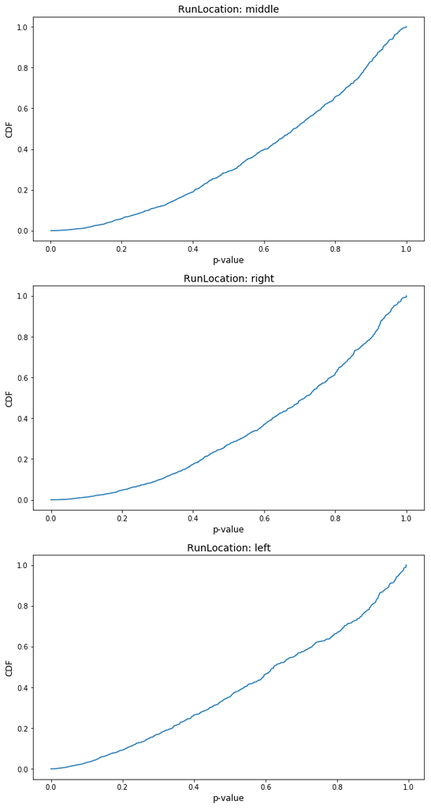

```python
fig, axs = plt.subplots(nrows=3, ncols=1, figsize=(10,20))

for i, ax in enumerate(axs):
    ax.plot(cdfs[i][1], cdfs[i][2])
    ax.set_xlabel('p-value', fontsize=12)
    ax.set_ylabel('CDF', fontsize=12)
    ax.set_title('RunLocation: ' + cdfs[i][0], fontsize=14)
plt.show()
```

**Figure 16:** P-value distributions for `RunLocation`

#### Query 14

I run similar tests for the Query 14 results, where I want to compare the difference in means between the passing yards of All Teams and PHI when facing common defensive units. I've wrapped the above code in the function `NflTtest` in a seperate file `nflttest.py`. The following queries are used to extract the relevant data:

```python
cnx = mysql.connector.connect(user=user,
                              password=password,
                              host=host,
                              database=database)

case1query = "SELECT p2.PassOutcome, p2.YardsGained FROM (SELECT DISTINCT DefensiveTeam AS DefTeam, posteam FROM plays WHERE posteam = 'PHI') AS p1 JOIN plays p2 ON p2.DefensiveTeam = p1.DefTeam WHERE p2.PassOutcome = 'Complete' AND p2.PassOutcome IS NOT NULL;"
case2query = "SELECT PassOutcome, YardsGained FROM plays WHERE posteam = 'PHI' AND PassOutcome = 'Complete';"
case1_df = pd.read_sql(case1query, con=cnx)
case2_df = pd.read_sql(case2query, con=cnx)

cnx.close()
```

```
Difference in Means between Avg. Pass Yds.:

	Difference in Means	p-value 	seed
	0.789989662618    	0.688813594986	5
```

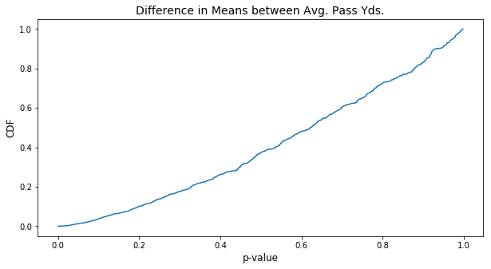

```python
import nflttest
imp.reload(nflttest)

nflttest.NflTtest(case1_df, case2_df, 'PassOutcome', ['Complete'], 'Difference in Means between Avg. Pass Yds.')
```

**Figure 17:** P-value distributions for Difference in Means

Again, the null hypothesis cannot be rejected so I cannot make any statistically significant claims about whether or not the Eagles gained more or less passing yards on average than other teams who faced common defenders.

#### Query 15

I run a chi-square test for the Query 15 results, where I want to compare the difference in average completion percentage between All Teams and PHI, when facing common defensive units. I've wrapped a function similar to the ones used in Queries 13 and 14, but now with `scipy.stats.chisquare` in a seperate file `nflttest.py`. The following queries are used to extract the relevant data:

```python
cnx = mysql.connector.connect(user=user,
                              password=password,
                              host=host,
                              database=database)

case1query = "SELECT p2.PassOutcome FROM (SELECT DISTINCT DefensiveTeam AS DefTeam, posteam FROM plays WHERE posteam = 'PHI') AS p1 JOIN plays p2 ON p2.DefensiveTeam = p1.DefTeam WHERE p2.PassOutcome IS NOT NULL;"
case2query = "SELECT PassOutcome FROM plays WHERE posteam = 'PHI' AND PassOutcome IS NOT NULL;"
case1_df = pd.read_sql(case1query, con=cnx)
case2_df = pd.read_sql(case2query, con=cnx)

cnx.close()
```

```python
comp_ratio = 4901/(4901+3012)
inc_ratio = 1 - comp_ratio
scipy.stats.chisquare([422,238], [comp_ratio*(422+238), inc_ratio*(422+238)])
```

```
Power_divergenceResult(statistic=1.1235583672166281, pvalue=0.28915353364878577)
```

```python
#All Teams PassOutcome
case1_df.PassOutcome.value_counts()
```

```
Complete           4901
Incomplete Pass    3012
Name: PassOutcome, dtype: int64
```

```python
#PHI PassOutcome
case2_df.PassOutcome.value_counts()
```

```
Complete           422
Incomplete Pass    238
Name: PassOutcome, dtype: int64
```

I wrap some code for calculating the chi-square statistic into a function `CompletionsChiSquare` and iterate 1000 times, resampling the DataFrames each time:

```python
def CompletionsChiSquare(obs, exp):
    obs_completions = len(obs.query("PassOutcome == 'Complete'"))
    obs_incompletes = len(obs.query("PassOutcome == 'Incomplete Pass'"))
    exp_completions = len(exp.query("PassOutcome == 'Complete'"))
    exp_incompletes = len(exp.query("PassOutcome == 'Incomplete Pass'"))

    exp_proportions = [1 / len(exp) * exp_completions, 1 / len(exp) * exp_incompletes]
    observed = [obs_completions, obs_incompletes]
    expected = [exp_proportions[0] * len(obs), exp_proportions[1] * len(obs)]
    return scipy.stats.chisquare(observed, expected)
p_values = []

for i in range(1000):
    np.random.seed(i)
    obs = pd.DataFrame(np.random.choice(case2_df.PassOutcome, len(case2_df)), columns=['PassOutcome'])
    exp = pd.DataFrame(np.random.choice(case1_df.PassOutcome, len(case1_df)), columns=['PassOutcome'])
    result = CompletionsChiSquare(obs, exp)
    p_values.append(result[1])
```

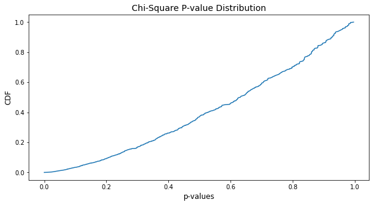

```python
imp.reload(nflttest)
nflttest.PlotCDF(p_values, 'p-values', 'Chi-Square P-value Distribution')
```

**Figure 18:** P-value distributions for Difference in `PassOutcome` Frequencies

The resulting p-values are close to being uniformly distributed, so we cannot reject the null hypothesis. In other words, there is no evidence to make any claims about whether or not the Eagles' `PassOutcome` frequencies are any different than other teams who faced the same defensive units.

### Future Steps

The play-by-play dataset opens up a plethora of questions that can be explored, so I will have no shortage of analysis material in the future posts related to this dataset. I'd like to dig deeper into the Eagles' offensive and defensive performance throughout the season, and look for trends/patterns to help understand which factors (play calls, field position, formations, etc) helped them succeed (first downs, touchdowns, made field goals) and which factors hurt (interceptions, fumbles, penalties) their success.